# EDE_Final_Project

2023-11-25

The null hypothesis: Electricity load in ERCOT remained the same from 2010 to 2023. Alternative hypothesis: Electricity load in ERCOT has changed from 2010 to 2023.

```r
# Read the CSV files
x2010<- read_excel("ERCOT_Source_Data/2010_ercot_hourly_load_data.xls") %>% rename(Hour_Ending = Hour_End) %>%
  mutate(Hour_Ending = as.Date(Hour_Ending, format = "%m/%d/%Y"))
x2011<- read_excel("ERCOT_Source_Data/2011_ercot_hourly_load_data.xls") %>% rename(Hour_Ending = Hour_End) %>%
  mutate(Hour_Ending = as.Date(Hour_Ending, format = "%m/%d/%Y"))
x2012<- read_excel("ERCOT_Source_Data/2012_ercot_hourly_load_data.xls") %>% rename(Hour_Ending = Hour_End) %>%
  mutate(Hour_Ending = as.Date(Hour_Ending, format = "%m/%d/%Y"))
x2013<- read_excel("ERCOT_Source_Data/2013_ercot_hourly_load_data.xls") %>% rename(Hour_Ending = Hour_End) %>%
  mutate(Hour_Ending = as.Date(Hour_Ending, format = "%m/%d/%Y"))
x2014<- read_excel("ERCOT_Source_Data/2014_ercot_hourly_load_data.xls") %>% rename(Hour_Ending = Hour_End) %>%
  mutate(Hour_Ending = as.Date(Hour_Ending, format = "%m/%d/%Y"))
x2015<- read_excel("ERCOT_Source_Data/native_load_2015.xls") %>% rename(Hour_Ending = Hour_End) %>%
  mutate(Hour_Ending = as.Date(Hour_Ending, format = "%m/%d/%Y"))
x2016<- read_excel("ERCOT_Source_Data/native_Load_2016.xlsx") %>% rename(Hour_Ending = Hour_End) %>%
  mutate(Hour_Ending = as.Date(Hour_Ending, format = "%m/%d/%Y"))
x2017<- read_excel("ERCOT_Source_Data/native_Load_2017.xlsx") %>% rename(Hour_Ending = "Hour Ending") %>%
  mutate(Hour_Ending = as.Date(Hour_Ending, format = "%m/%d/%Y"))
x2018<- read_excel("ERCOT_Source_Data/Native_Load_2018.xlsx") %>% rename(Hour_Ending = "HourEnding") %>%
  mutate(Hour_Ending = as.Date(Hour_Ending, format = "%m/%d/%Y"))
x2019<- read_excel("ERCOT_Source_Data/Native_Load_2019.xlsx") %>% rename(Hour_Ending = "HourEnding") %>%
  mutate(Hour_Ending = as.Date(Hour_Ending, format = "%m/%d/%Y"))
x2020<- read_excel("ERCOT_Source_Data/Native_Load_2020.xlsx") %>% rename(Hour_Ending = "HourEnding") %>%
  mutate(Hour_Ending = as.Date(Hour_Ending, format = "%m/%d/%Y"))
x2021<- read_excel("ERCOT_Source_Data/Native_Load_2021.xlsx") %>% rename(Hour_Ending = "Hour Ending") %>%
  mutate(Hour_Ending = as.Date(Hour_Ending, format = "%m/%d/%Y"))
x2022<- read_excel("ERCOT_Source_Data/Native_Load_2022.xlsx") %>% rename(Hour_Ending = "Hour Ending") %>%
  mutate(Hour_Ending = as.Date(Hour_Ending, format = "%m/%d/%Y"))
x2023<- read_excel("ERCOT_Source_Data/Native_Load_2023.xlsx") %>% rename(Hour_Ending = "Hour Ending") %>%
  mutate(Hour_Ending = as.Date(Hour_Ending, format = "%m/%d/%Y"))

# Merge the data frames based on a common column
ercot <- bind_rows(x2010, x2011, x2012, x2013, x2014, x2015, x2016, x2017, x2018, x2019, x2020, x2021, x2022, x2023)
head(ercot)
```

```
## # A tibble: 6 × 14
##   Hour_Ending COAST  EAST FAR_WEST NORTH NORTH_C SOUTHERN SOUTH_C  WEST  ERCOT
##   <date>      <dbl> <dbl>    <dbl> <dbl>   <dbl>    <dbl>   <dbl> <dbl>  <dbl>
## 1 2010-01-01  7775. 1238.    1238.  878.  12406.    2468.   5032. 1060. 32094.
## 2 2010-01-01  7705. 1236.    1249.  884.  12486.    2436.   5111. 1065. 32171.
## 3 2010-01-01  7651. 1244.    1251.  881.  12559.    2414.   5169. 1072. 32242.
## 4 2010-01-01  7667. 1253.    1260.  894.  12672.    2384.   5242. 1087. 32459.
## 5 2010-01-01  7745. 1284.    1265.  906.  12912.    2498.   5401. 1112. 33124.
## 6 2010-01-01  7981. 1337.    1281.  939.  13361.    2597.   5660. 1159. 34315.
## # … with 4 more variables: FWEST <dbl>, NCENT <dbl>, SOUTH <dbl>, SCENT <dbl>
```

```r
# Plot hourly data

ercot_load <- ercot %>%
  select(Hour_Ending,ERCOT)

head(ercot_load)
```

```
## # A tibble: 6 × 2
##   Hour_Ending  ERCOT
##   <date>       <dbl>
## 1 2010-01-01  32094.
## 2 2010-01-01  32171.
## 3 2010-01-01  32242.
## 4 2010-01-01  32459.
## 5 2010-01-01  33124.
## 6 2010-01-01  34315.
```

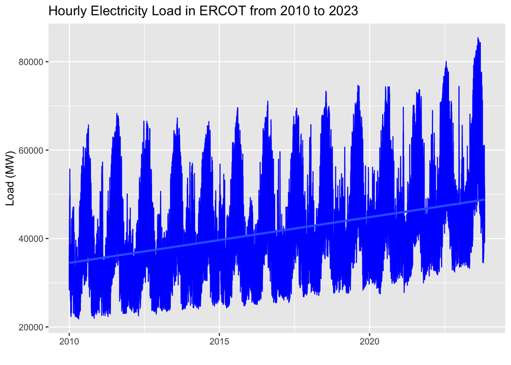

```r
ggplot(ercot_load, aes(x = Hour_Ending, y = ERCOT)) +
  geom_line(color = "blue") +
  geom_smooth(method = "lm") +
  ggtitle('Hourly Electricity Load in ERCOT from 2010 to 2023') +
  labs(x = "", y = "Load (MW)")
```

```r
#Aggregate data by month

ercot_load_monthly <- ercot_load %>%
  mutate(
    Year = year(Hour_Ending),
    Month = month(Hour_Ending)
  ) %>%
  group_by(Year, Month) %>%
  summarise(
    Mean_Load = mean(ERCOT, na.rm = TRUE)
  )
ercot_load_monthly$NewDate <-
  as.Date(paste(ercot_load_monthly$Year, ercot_load_monthly$Month, "01", sep = "-"))

head(ercot_load_monthly)
```

```
## # A tibble: 6 × 4
## # Groups:   Year [1]
##    Year Month Mean_Load NewDate
##   <dbl> <dbl>     <dbl> <date>
## 1  2010     1    34884. 2010-01-01
## 2  2010     2    35240. 2010-02-01
## 3  2010     3    29550. 2010-03-01
## 4  2010     4    29856. 2010-04-01
## 5  2010     5    36547. 2010-05-01
## 6  2010     6    44000. 2010-06-01
```

```r
#Aggregate data by day

ercot_load_daily<- ercot_load %>%
  mutate(
    Year = year(Hour_Ending),
    Month = month(Hour_Ending),
    Day = day (Hour_Ending)
  ) %>%
  group_by(Year, Month, Day) %>%
  summarise(
    Mean_Load = mean(ERCOT, na.rm = TRUE)
  )
ercot_load_daily$NewDate <-
  as.Date(paste(ercot_load_daily$Year, ercot_load_daily$Month,ercot_load_daily$Day, sep = "-"))

head(ercot_load_daily)
```

```
## # A tibble: 6 × 5
## # Groups:   Year, Month [1]
##    Year Month   Day Mean_Load NewDate
##   <dbl> <dbl> <int>     <dbl> <date>
## 1  2010     1     1    33080. 2010-01-01
## 2  2010     1     2    33780. 2010-01-02
## 3  2010     1     3    33892. 2010-01-03
## 4  2010     1     4    38857. 2010-01-04
## 5  2010     1     5    40971. 2010-01-05
## 6  2010     1     6    39005. 2010-01-06
```

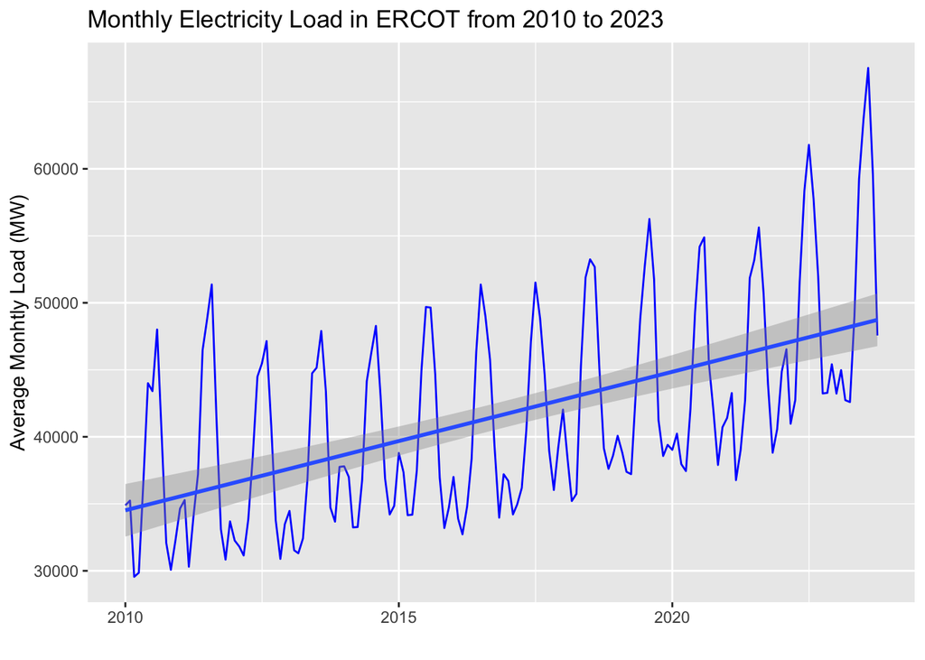

```r
graph1 <- ggplot(ercot_load_monthly, aes(x = NewDate, y = Mean_Load)) +
  geom_line(color = "blue") +
  geom_smooth(method = "lm") +
  ggtitle('Monthly Electricity Load in ERCOT from 2010 to 2023') +
  labs(x = "", y = "Average Monhtly Load (MW)")

graph1
```

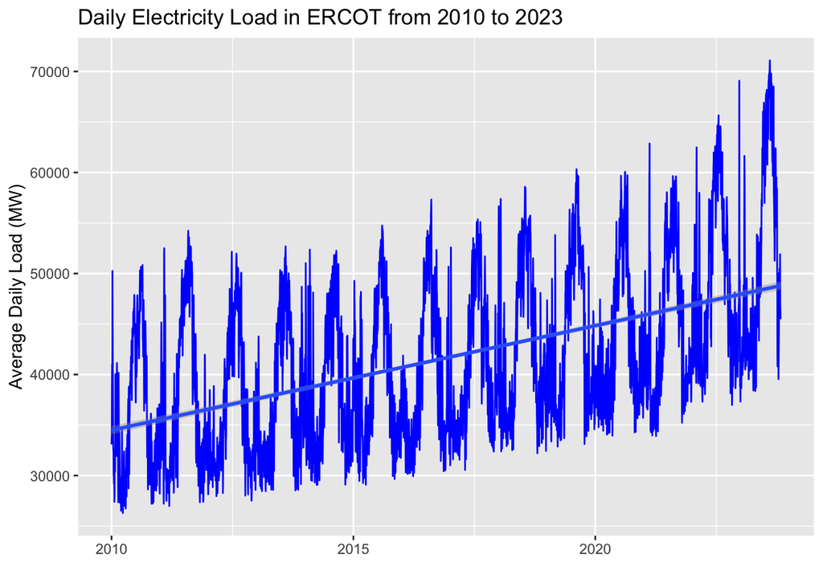

```r
graph2 <- ggplot(ercot_load_daily, aes(x = NewDate, y = Mean_Load)) +
  geom_line(color = "blue") +
  geom_smooth(method = "lm") +
  ggtitle('Daily Electricity Load in ERCOT from 2010 to 2023') +
  labs(x = "", y = "Average Daily Load (MW)")

graph2
```

```r
#Generate ts dataframes

ercot_load_daily_ts <- ts(
  ercot_load_daily$Mean_Load,
  start = c(2010,1), frequency = 365
)

ercot_load_monthly_ts <- ts(
  ercot_load_daily$Mean_Load,
  start = c(2010,1),
  frequency = 12
)
```

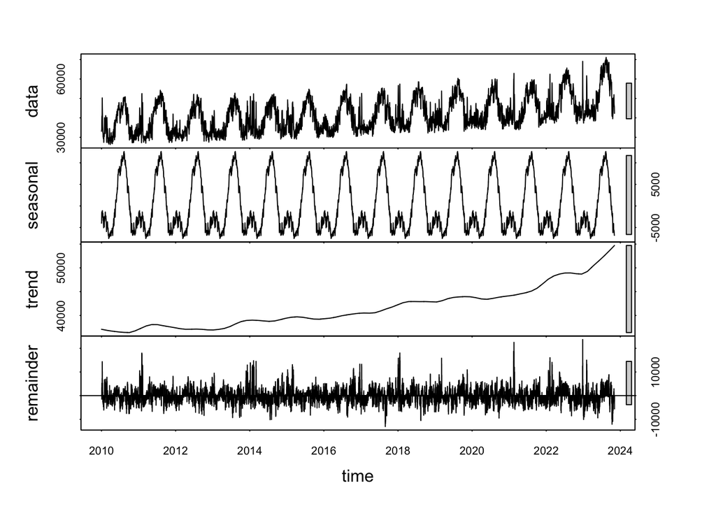

```r
#11 Decompose ts dfs and plot them

daily_decomposed <- stl(ercot_load_daily_ts, s.window="periodic")
plot(daily_decomposed)
```

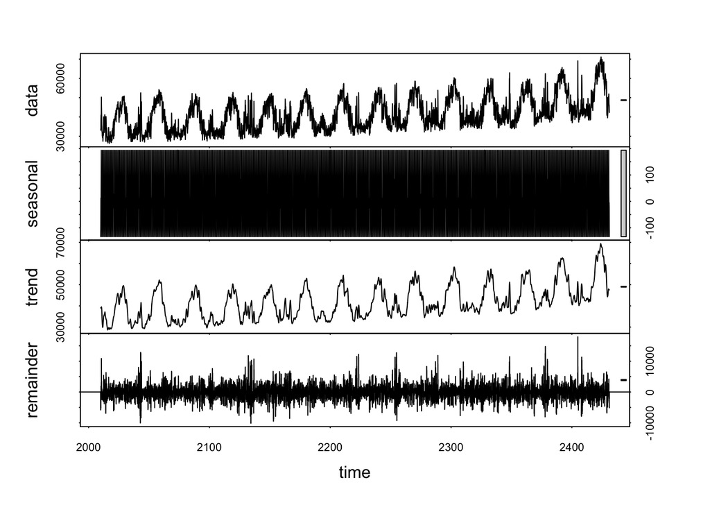

```r
monthly_decomposed <- stl(ercot_load_monthly_ts, s.window="periodic")
plot(monthly_decomposed)
```

```r
monthly_load_trend <- Kendall::SeasonalMannKendall(ercot_load_monthly_ts)
summary(monthly_load_trend)
```

```
## Score =  361963 , Var(Score) = 99903723
## denominator =  1061341
## tau = 0.341, 2-sided pvalue =< 2.22e-16
```

The seasonal Mann-Kendall is the most appropriate test because it is designed to analyze seasonal, non-parametric data, and there is a clear seasonal trend in our data. All other tests we learned about could only be used for non-seasonal data. A positive score (361963) and tau (0.341) indicate an increasing trend in the time series data. The p-value smaller than 0.05 allows us to reject the null hypothesis. Therefore, we can conclude that electricity demand has changed over time in ERCOT.

```r
# Extract seasonal component from the time series

monthly_decomposed_components <- as.data.frame(monthly_decomposed$time.series[,1:3])

monthly_decomposed_deseasoned <-
  ercot_load_monthly_ts-monthly_decomposed_components$seasonal

# Run the Mann Kendall test on the non-seasonal data

monthly_load_trend_deseason <- Kendall::MannKendall(monthly_decomposed_deseasoned)
summary(monthly_load_trend_deseason)
```

```
## Score =  4339158 , Var(Score) = 14339508224
## denominator =  12763877
## tau = 0.34, 2-sided pvalue =< 2.22e-16
```

Based on the results of the Mann Kendall test, we are able to reject the null hypothesis (p<0.05) and identify an increasing trend in the data (tau=0.34, score=4339158). Hence, the load in ERCOT has indeed changed over time; it was not simply a seasonal change. A p-value <0.05 in the seasonal Mann Kendall test also led us to the same conclusion.